# Portfolio Construction & Optimization

Date: April 26, 2025

Author: [Renan Peres](https://renanperes.com/)

[View Source Code](https://github.com/renan-peres/mfin-portfolio-management)

This dashboard showcases an end-to-end process used for building and optimizing investment portfolios to support clients with their investment decisions. The methodology takes into account the risk-free rate, current market conditions, the client’s risk tolerance, and the diversification component from the risk–return profile of individual securities.

**Note**

This project is for **educational use only**.

It supports the accompanying Investment Policy Statement (IPS) and reflects the author’s opinions and analysis. No portion may be reproduced or distributed for commercial purposes without prior written consent.

**Tip**

Responsive sidebar

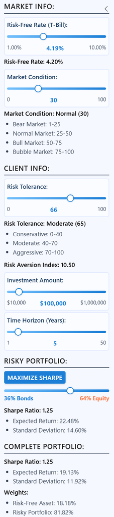

inputs (located on the left side of the screen) — adjust the values and all the calculation, charts, and tables will be updated accordingly.

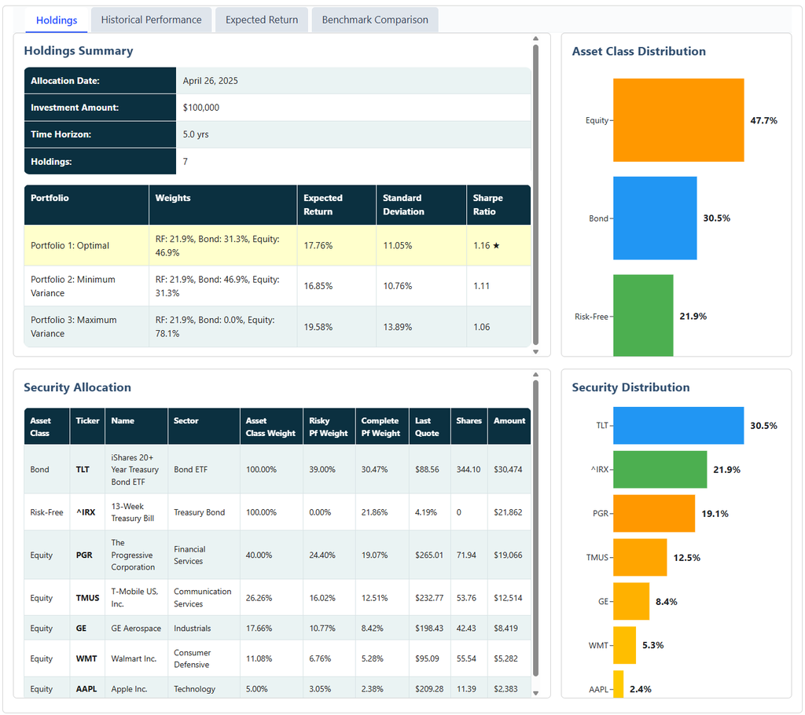

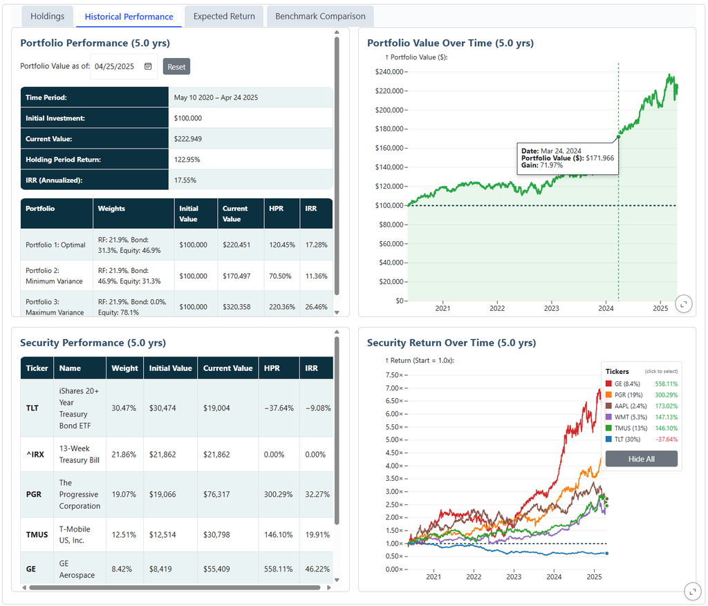

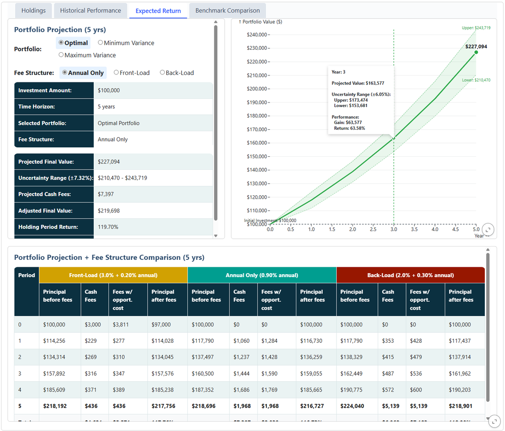

**Portfolio Holdings**

**Performance Analysis**

**Future Projections**

Overview of current investment holdings

Historical returns and risk metrics

Estimated growth scenarios and fee structure comparison

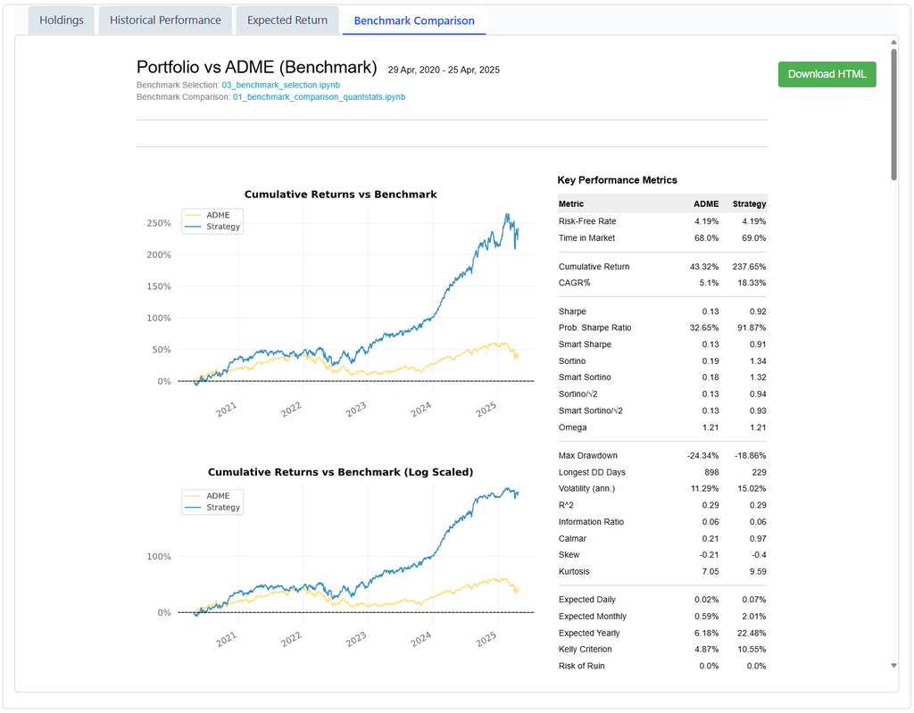

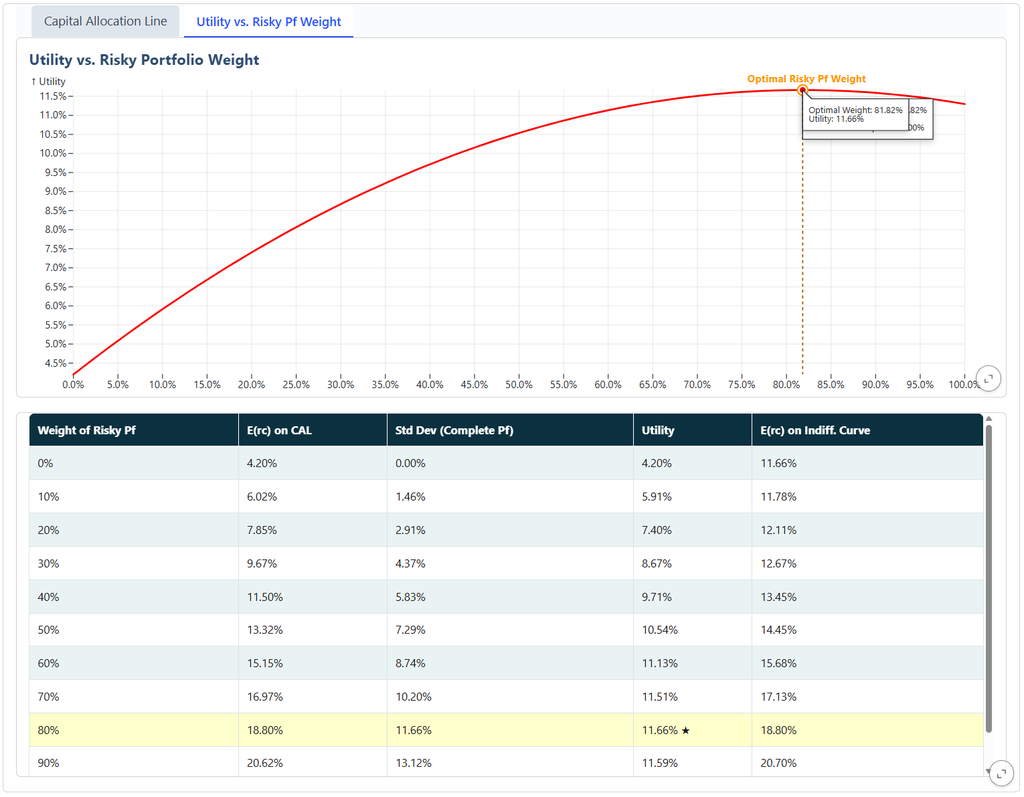

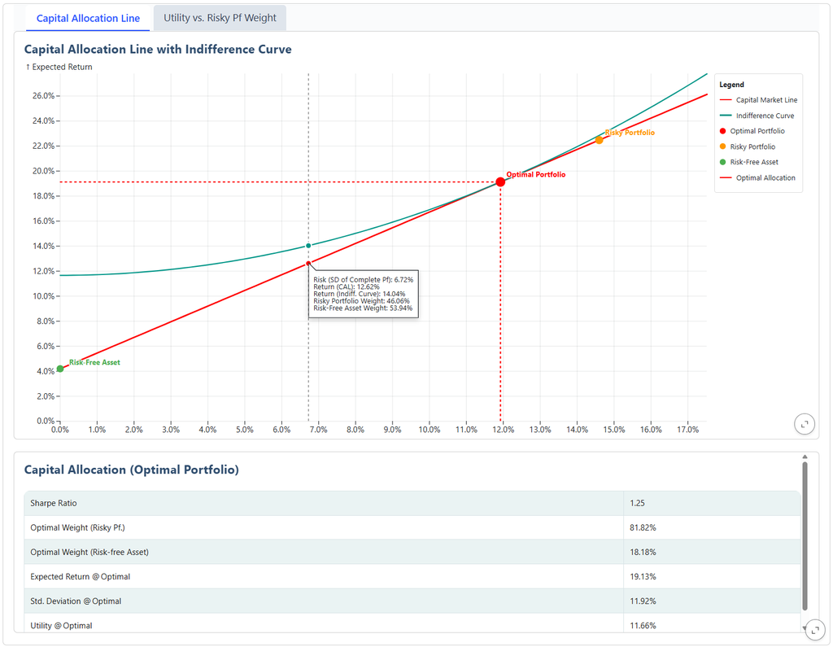

**Benchmark Comparison**

**Utility Weight Analysis**

**Capital Allocation Line**

Historical portfolio performance against benchmark

Risk aversion and utility-based portfolio weights

Optimal allocation between risky and risk-free assets

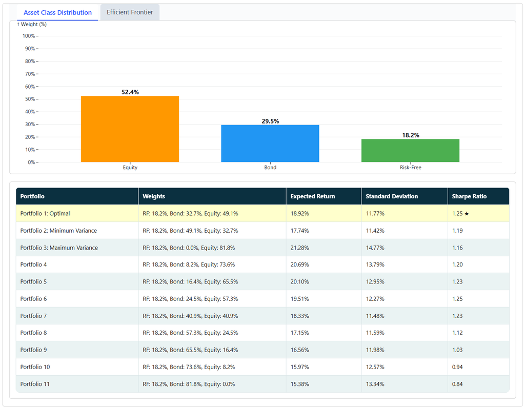

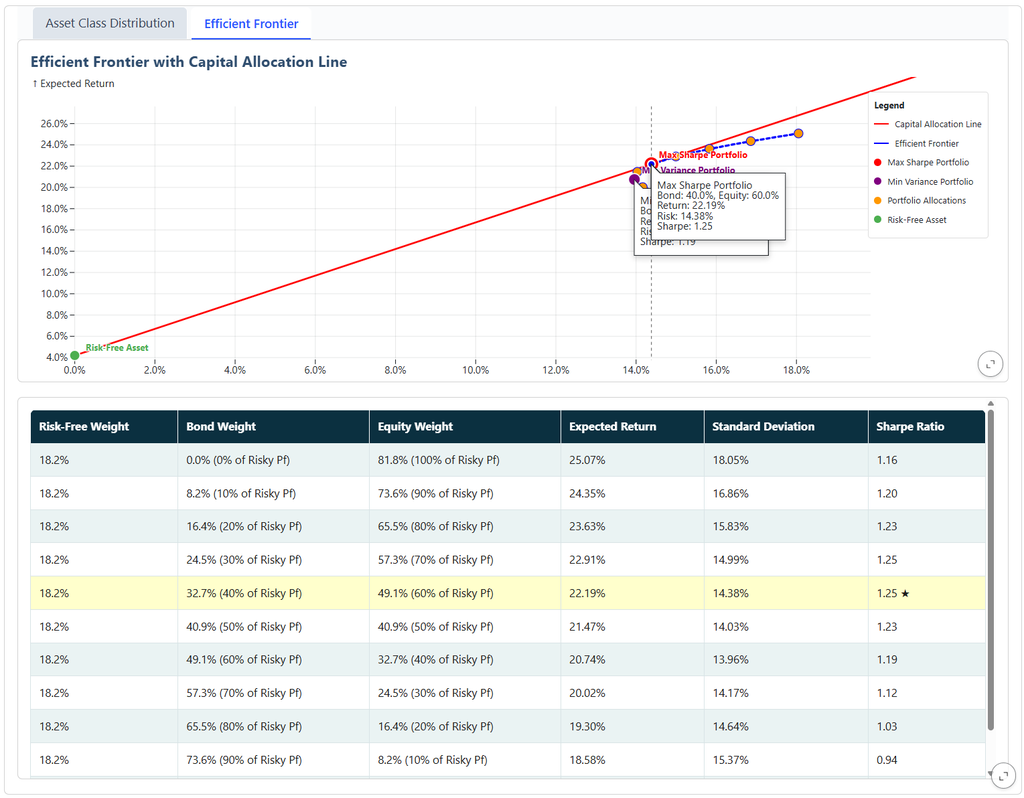

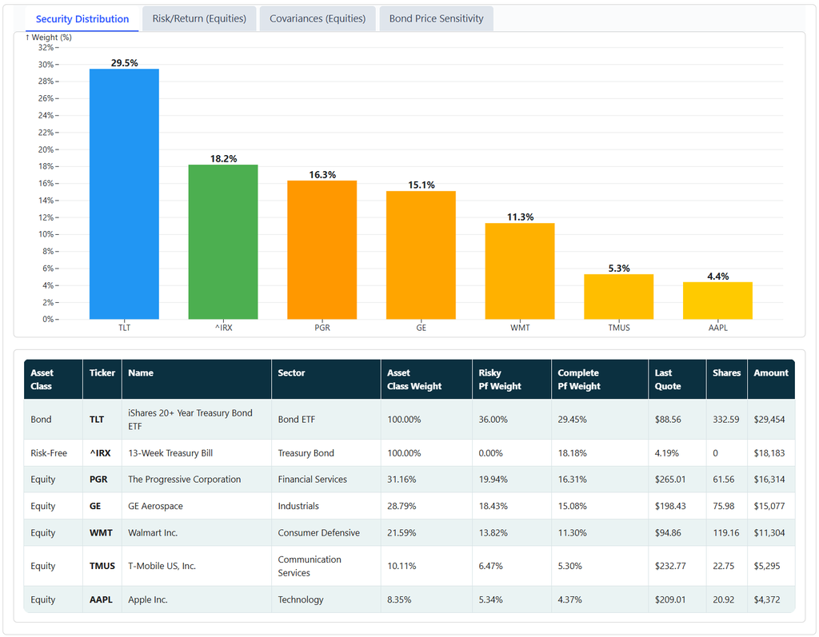

**Asset Class Distribution**

**Asset Class Efficient Frontier**

**Security Distribution**

Breakdown of portfolio by asset classes

Risk-return profile of asset class allocations

Individual security weightings within the portfolio

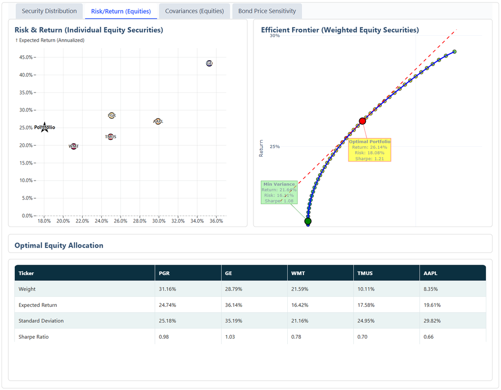

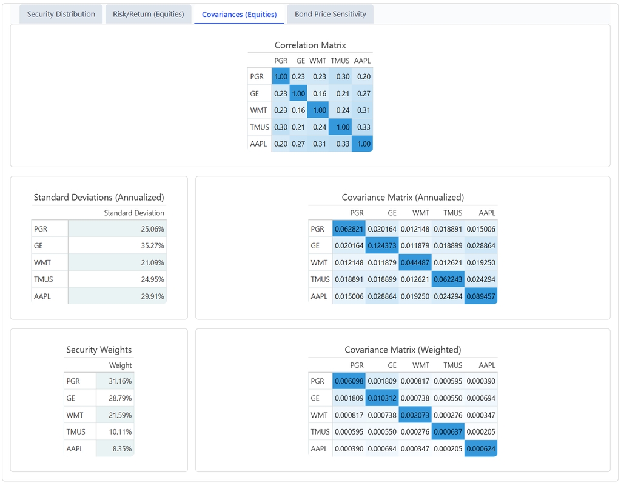

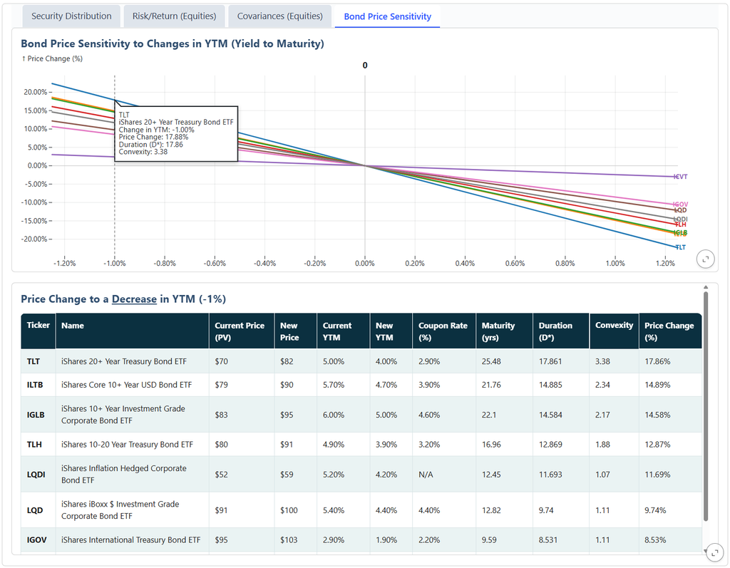

**Equity Efficient Frontier**

**Equity Covariances**

**Bond Price Sensitivity**

Risk-return profile of individual securities

Correlation analysis between equity holdings

Fixed income response to interest rate changes

### Contents

| Section | Description |
| --- | --- |
| Portfolio | Holdings, historical performance, expected return (with fee structure), and benchmark comparison |
| Capital Allocation | Split between risk-free and risky assets based on the client’s risk tolerance (with utility functions) |
| Asset Class Allocation | Weights across major asset classes with risk–return scenarios |
| Security Allocation | Individual securities risk–return metrics, efficient frontier, covariances, and bond-price sensitivity to YTM |
| Data | Raw datasets powering the dashboard |
| Excel Models | Underlying portfolio-construction models |
| IPS | Investment Policy Statement document |

### Security Selection

- **Equity Selection**: 01_equity_portfolio_construction.ipynb  
  Equity selection using fundamental analysis and Sharpe ratio maximization.
- **Bond Selection**: 02_bond_portfolio_contruction.ipynb  
  Fixed-income ETF screening for convexity > 1 and higher price sensitivity to changes in yield-to-maturity (YTM).
- **Benchmark Selection**: 03_benchmark_selection.ipynb  
  Regression analysis to identify an ETF (that invests in the same sectors) with the best fit to serve as the benchmark for the portfolio’s performance comparison.

**Holdings**

[interactive chart not shown]

**Historical Performance**

[interactive chart not shown]

**Expected Return**

[interactive chart not shown]

**Benchmark Comparison**

[interactive chart not shown]

**Capital Allocation Line**

[interactive chart not shown]

**Utility vs. Risky Pf Weight**

[interactive chart not shown]

**Asset Class Distribution**

[interactive chart not shown]

**Efficient Frontier**

[interactive chart not shown]

**Security Distribution**

[interactive chart not shown]

**Risk/Return (Equities)**

[interactive chart not shown]

##### Optimal Equity Portfolio Weights

| Ticker | PGR | GE | WMT | TMUS | AAPL |
| --- | --- | --- | --- | --- | --- |
| Weight | 31.16% | 28.79% | 21.59% | 10.11% | 8.35% |
| Expected Return | 24.74% | 36.14% | 16.42% | 17.58% | 19.61% |
| Standard Deviation | 25.18% | 35.19% | 21.16% | 24.95% | 29.82% |

**Covariances (Equities)**

Correlation Matrix

|  | PGR | GE | WMT | TMUS | AAPL |
| --- | --- | --- | --- | --- | --- |
| PGR | 1.00 | 0.23 | 0.23 | 0.30 | 0.20 |
| GE | 0.23 | 1.00 | 0.16 | 0.21 | 0.27 |
| WMT | 0.23 | 0.16 | 1.00 | 0.24 | 0.31 |
| TMUS | 0.30 | 0.21 | 0.24 | 1.00 | 0.33 |
| AAPL | 0.20 | 0.27 | 0.31 | 0.33 | 1.00 |

Standard Deviations (Annualized)

|  | Standard Deviation |
| --- | --- |
| PGR | 25.06% |
| GE | 35.27% |
| WMT | 21.09% |
| TMUS | 24.95% |
| AAPL | 29.91% |

Covariance Matrix (Annualized)

|  | PGR | GE | WMT | TMUS | AAPL |
| --- | --- | --- | --- | --- | --- |
| PGR | 0.062821 | 0.020164 | 0.012148 | 0.018891 | 0.015006 |
| GE | 0.020164 | 0.124373 | 0.011879 | 0.018899 | 0.028864 |
| WMT | 0.012148 | 0.011879 | 0.044487 | 0.012621 | 0.019250 |
| TMUS | 0.018891 | 0.018899 | 0.012621 | 0.062243 | 0.024294 |
| AAPL | 0.015006 | 0.028864 | 0.019250 | 0.024294 | 0.089457 |

Security Weights

|  | Weight |
| --- | --- |
| PGR | 31.16% |
| GE | 28.79% |
| WMT | 21.59% |
| TMUS | 10.11% |
| AAPL | 8.35% |

Covariance Matrix (Weighted)

|  | PGR | GE | WMT | TMUS | AAPL |
| --- | --- | --- | --- | --- | --- |
| PGR | 0.006098 | 0.001809 | 0.000817 | 0.000595 | 0.000390 |
| GE | 0.001809 | 0.010312 | 0.000738 | 0.000550 | 0.000694 |
| WMT | 0.000817 | 0.000738 | 0.002073 | 0.000276 | 0.000347 |
| TMUS | 0.000595 | 0.000550 | 0.000276 | 0.000637 | 0.000205 |
| AAPL | 0.000390 | 0.000694 | 0.000347 | 0.000205 | 0.000624 |

**Bond Price Sensitivity**

[interactive chart not shown]

**Security Quotes**

**Daily**

Adjusted Closing Price (5Y Daily)

Date

GE

PGR

WMT

AAPL

TMUS

^IRX

TLT

ADME

[figure not shown]

**Monthly**

Adjusted Closing Price (5Y Monthly)

Date

GE

PGR

WMT

AAPL

TMUS

^IRX

TLT

ADME

[figure not shown]

**Stock Fundamentals**

| Ticker | AAPL | GE | PGR | TMUS | WMT |
| --- | --- | --- | --- | --- | --- |
| Name | Apple Inc. | GE Aerospace | The Progressive Corporation | T-Mobile US, Inc. | Walmart Inc. |
| Date | 2025-05-19 | 2025-05-19 | 2025-05-19 | 2025-05-19 | 2025-05-19 |
| Sector | Technology | Industrials | Financial Services | Communication Services | Consumer Defensive |
| Industry | Consumer Electronics | Aerospace & Defense | Insurance - Property & Casualty | Telecom Services | Discount Stores |
| Country | United States | United States | United States | United States | United States |
| Website | https://www.apple.com | https://www.geaerospace.com | https://www.progressive.com | https://www.t-mobile.com | https://corporate.walmart.com |
| Market Cap | 3,116,055,920,640.00 | 250,158,039,040.00 | 169,310,289,920.00 | 278,633,742,336.00 | 785,687,379,968.00 |
| Enterprise Value | 3,205,030,477,824.00 | 255,093,096,448.00 | 171,781,554,176.00 | 385,216,118,784.00 | 851,749,634,048.00 |
| Float Shares | 14,911,480,604.00 | 1,062,600,970.00 | 584,025,304.00 | 1,041,100,974.00 | 4,346,047,610.00 |
| Shares Outstanding | 14,935,799,808.00 | 1,066,390,016.00 | 586,224,000.00 | 1,135,449,984.00 | 8,000,889,856.00 |
| P/E (trailing) | 32.50 | 36.94 | 19.49 | 23.96 | 41.97 |
| P/E (forward) | 25.11 | 44.77 | 20.93 | 23.00 | 36.10 |
| P/S | 7.78 | 6.30 | 2.16 | 3.37 | 1.15 |
| P/B | 46.66 | 12.99 | 5.85 | 4.57 | 9.39 |
| EV/EBITDA | 23.08 | 26.13 | 14.84 | 12.19 | 20.04 |
| EV/Revenue | 8.01 | 6.43 | 2.19 | 4.66 | 1.24 |
| Gross Margin (%) | 46.63% | 31.88% | 14.98% | 63.85% | 24.88% |
| EBITDA Margin (%) | 34.68% | 24.60% | 14.74% | 38.22% | 6.20% |
| Operating Margin (%) | 31.03% | 21.98% | 16.20% | 22.98% | 4.31% |
| Profit Margin (%) | 24.30% | 17.63% | 11.10% | 14.41% | 2.75% |
| ROE | 1.38 | 0.27 | 0.34 | 0.19 | 0.22 |
| ROA | 0.24 | 0.04 | 0.07 | 0.06 | 0.07 |
| Revenue (TTM) | 400,366,010,368.00 | 39,680,999,424.00 | 78,507,999,232.00 | 82,691,997,696.00 | 685,086,015,488.00 |
| Revenue Growth (%) | 5.10% | 10.90% | 18.40% | 6.60% | 2.50% |
| EPS (trailing) | 6.42 | 6.35 | 14.82 | 10.24 | 2.34 |
| EPS (forward) | 8.31 | 5.24 | 13.80 | 10.67 | 2.72 |
| Earnings Growth (%) | 7.80% | 31.40% | 10.90% | 29.00% | -11.10% |
| Earnings Quarterly Growth (%) | 4.80% | 28.50% | 10.10% | 24.40% | -12.10% |
| Total Cash | 48,497,999,872.00 | 13,004,999,680.00 | 2,790,000,128.00 | 12,003,000,320.00 | 9,310,999,552.00 |
| Total Debt | 98,186,002,432.00 | 20,714,000,384.00 | 6,894,000,128.00 | 121,691,996,160.00 | 67,205,001,216.00 |
| Debt to Equity | 146.99 | 106.4 | 23.81 | 199.15 | 74.14 |
| Current Ratio | 0.82 | 1.08 | 0.33 | 1.16 | 0.78 |
| Quick Ratio | 0.68 | 0.73 | 0.26 | 0.9 | 0.18 |
| Book Value | 4.47 | 18.05 | 49.41 | 53.73 | 10.46 |
| Free Cash Flow | 97,251,500,032.00 | 2,622,874,880.00 | 13,350,724,608.00 | 9,022,624,768.00 | 9,801,124,864.00 |
| Operating Cash Flow | 109,555,998,720.00 | 5,224,999,936.00 | 16,026,999,808.00 | 24,056,000,512.00 | 37,604,999,168.00 |
| Dividend Yield (%) | 0.49% | 0.62% | 1.71% | 1.45% | 0.96% |
| Dividend Rate (%) | 1.04% | 1.44% | 4.90% | 3.52% | 0.94% |
| 5Y Avg Dividend Yield (%) | 0.57% | 0.40% | 1.58% | 0.00% | 1.43% |
| Payout Ratio (%) | 15.58% | 23.34% | 33.04% | 29.88% | 36.65% |
| Price | 208.63 | 234.58 | 288.82 | 245.4 | 98.2 |
| Target Price | 229.61 | 226.9 | 294.88 | 269.57 | 107.88 |
| Target High | 300 | 261 | 330 | 305 | 120 |
| Target Low | 170.62 | 196.11 | 183.0 | 202.99 | 64.0 |
| Analyst Rating | buy | strong_buy | buy | buy | buy |
| Analyst Rating Value | 2.09 | 1.4 | 2.25 | 2.03 | 1.51 |
| Beta | 1.27 | 1.31 | 0.4 | 0.68 | 0.7 |
| 52W High | 260.1 | 234.67 | 292.99 | 276.49 | 105.3 |
| 52W Low | 169.21 | 150.2 | 201.34 | 163.15 | 63.87 |
| 50 Day Avg | 208.47 | 198.98 | 276.07 | 254.46 | 91.25 |
| 200 Day Avg | 226.24 | 185.9 | 256.33 | 230.63 | 87.55 |
| Short Ratio | 1.43 | 1.56 | 1.7 | 2.29 | 1.95 |
| Short % of Float | 0.01 | 0.01 | 0.01 | 0.03 | 0.01 |

**Bond Fundamentals**

| Ticker | TLT | ILTB | IGLB | TLH | LQDI | LQD | IGOV | ICVT |
| --- | --- | --- | --- | --- | --- | --- | --- | --- |
| Name | iShares 20+ Year Treasury Bond ETF | iShares Core 10+ Year USD Bond ETF | iShares 10+ Year Investment Grade Corporate Bo... | iShares 10-20 Year Treasury Bond ETF | iShares Inflation Hedged Corporate Bond ETF | iShares iBoxx $ Investment Grade Corporate Bon... | iShares International Treasury Bond ETF | iShares Convertible Bond ETF |
| Perf. as of | Apr 30, 2025 | Apr 30, 2025 | Apr 30, 2025 | Apr 30, 2025 | Apr 30, 2025 | Apr 30, 2025 | Apr 30, 2025 | Apr 30, 2025 |
| Inception Date | Jul 22, 2002 | Dec 08, 2009 | Dec 08, 2009 | Jan 05, 2007 | May 08, 2018 | Jul 22, 2002 | Jan 21, 2009 | Jun 02, 2015 |
| Net Assets | 48,796,891,937.00 | 591,313,158.00 | 2,498,390,313.00 | 9,898,819,870.00 | 90,392,195.00 | 29,697,566,053.00 | 976,165,647.00 | 2,472,301,830.00 |
| Bond_Price | 69.698 | 78.632 | 83.077 | 80.199 | 52.456 | 90.748 | 94.584 | 97.769 |
| Price Sensitivity to YTM (-1%) | 17.86% | 14.89% | 14.58% | 12.87% | 11.69% | 9.74% | 8.53% | 2.41% |
| Standard_Deviation | 16.30% | 12.85% | 12.74% | 12.88% | 8.89% | 8.82% | 9.54% | 15.14% |
| Duration (D*) | 17.861 | 14.885 | 14.584 | 12.869 | 11.693 | 9.74 | 8.531 | 2.413 |
| Convexity | 3.38 | 2.34 | 2.17 | 1.88 | 1.07 | 1.11 | 1.11 | 1.2 |
| Weighted_Avg_Maturity | 25.48 | 21.76 | 22.1 | 16.96 | 12.45 | 12.82 | 9.59 | 2.93 |
| Weighted_Avg_Coupon | 2.90% | 3.90% | 4.60% | 3.20% | 0.00% | 4.40% | 2.20% | 2.10% |
| Yield_To_Maturity | 5.00% | 5.70% | 6.00% | 4.90% | 5.20% | 5.40% | 2.90% | 2.90% |
| YTD (%) | 3.23% | 2.20% | 1.10% | 4.02% | 2.32% | 2.22% | 8.65% | 0.45% |
| 1Y (%) | 5.46% | 6.73% | 6.19% | 7.73% | 6.38% | 7.50% | 9.56% | 13.09% |
| 3Y (%) | -6.03% | -1.03% | 0.87% | -2.63% | 2.12% | 2.61% | -0.71% | 5.30% |
| 5Y (%) | -9.43% | -3.92% | -1.95% | -6.71% | 4.01% | -0.17% | -3.32% | 10.75% |
| 10Y (%) | -0.87% | 1.47% | 2.09% | -0.35% | 0 | 2.37% | -0.86% | 0 |
| Incept (%) | 3.79% | 3.87% | 4.27% | 2.95% | 3.95% | 4.41% | 0.21% | 9.08% |
| Product_ID | 239454 | 239424 | 239423 | 239453 | 294319 | 239566 | 239830 | 272819 |
| URL | https://www.blackrock.com/us/individual/produc... | https://www.blackrock.com/us/individual/produc... | https://www.blackrock.com/us/individual/produc... | https://www.blackrock.com/us/individual/produc... | https://www.blackrock.com/us/individual/produc... | https://www.blackrock.com/us/individual/produc... | https://www.blackrock.com/us/individual/produc... | https://www.blackrock.com/us/individual/produc... |

[interactive chart not shown]

**Market Info:**

[interactive chart not shown]

**Client Info:**

[interactive chart not shown]

**Risky Portfolio:**

[interactive chart not shown]

**Complete Portfolio:**

[interactive chart not shown]